# Introduction - Illustrative example (analysis with LMER)

Theophanis Tsandilas and Géry Casiez

We detail our analysis for the illustrative example presented in the Introduction.

We use data from a hypothetical experiment that evaluates the time performance of three user interface techniques (*A*, *B*, and *C*) that help users complete image editing tasks of four different difficulty levels: *Level1*, *Level2*, *Level3*, and *Level4*.

The experiment follows a fully balanced repeated-measures factorial design, where each participant ($N = 24$) performs 12 tasks in a unique order. The researchers measure the time that it takes participants to complete each task, but participants also evaluate the perceived efficiency, using an ordinal scale with five levels.

**Note:** We describe in detail the simulation process used to generate this dataset here.

### Preliminary

Let us first import all required libraries.

```r
library(lmerTest) # Lmer functions
library(ARTool) # ARTool library
library(effectsize) # To estimate effect sizes

library(car)

# Additional libraries for plotting and reporting
library(kableExtra)
library(gridExtra)
library(ggplot2)
library(tidyverse)
```

### Reading the dataset

We read our dataset and fix the type of the factors:

```r
df <- read.csv("illustrative-example-dataset.csv", sep=",", header=TRUE, strip.white=TRUE)

df$Participant <- factor(df$Participant)
df$Difficulty <- factor(df$Difficulty, ordered = TRUE) # We can consider it as ordinal
df$Technique <- factor(df$Technique)

df$Perceived_Efficiency <- ordered(df$Perceived_Efficiency, levels = c("inefficient", "somewhat inefficient", "neutral", "somewhat efficient", "efficient"))
```

We present our dataset with a table:

```r
kbl(df, booktabs = TRUE) %>% kable_styling(font_size=14) %>% kable_paper(position = "center") %>% scroll_box(height = "170px")
```

| Participant | Difficulty | Technique | Time | Perceived_Efficiency |
| --- | --- | --- | --- | --- |
| s1 | Level1 | A | 0.18 | somewhat efficient |
| s1 | Level2 | A | 0.52 | efficient |
| s1 | Level3 | A | 2.05 | efficient |
| s1 | Level4 | A | 1.48 | somewhat efficient |
| s1 | Level1 | B | 0.27 | efficient |
| s1 | Level2 | B | 0.85 | efficient |
| s1 | Level3 | B | 1.80 | efficient |
| s1 | Level4 | B | 1.93 | efficient |
| s1 | Level1 | C | 0.19 | efficient |
| s1 | Level2 | C | 0.38 | efficient |
| s1 | Level3 | C | 1.17 | efficient |
| s1 | Level4 | C | 1.70 | somewhat efficient |
| s2 | Level1 | A | 0.23 | efficient |
| s2 | Level2 | A | 0.64 | efficient |
| s2 | Level3 | A | 1.12 | efficient |
| s2 | Level4 | A | 3.51 | efficient |
| s2 | Level1 | B | 0.17 | efficient |
| s2 | Level2 | B | 0.47 | efficient |
| s2 | Level3 | B | 1.08 | efficient |
| s2 | Level4 | B | 4.19 | efficient |
| s2 | Level1 | C | 0.09 | efficient |
| s2 | Level2 | C | 0.52 | somewhat efficient |
| s2 | Level3 | C | 0.96 | efficient |
| s2 | Level4 | C | 0.93 | efficient |
| s3 | Level1 | A | 0.86 | somewhat efficient |
| s3 | Level2 | A | 4.30 | somewhat efficient |
| s3 | Level3 | A | 3.63 | efficient |
| s3 | Level4 | A | 6.70 | somewhat efficient |
| s3 | Level1 | B | 2.63 | efficient |
| s3 | Level2 | B | 4.52 | somewhat efficient |

[output cut: 258 more lines]

### Plotting the data

We then plot our data to observe the main trends.

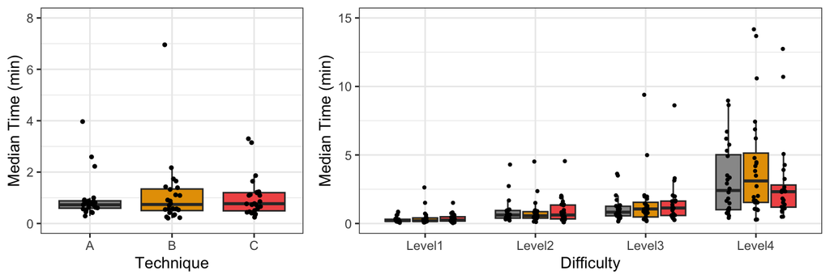

```r
cbPalette <- c("#999999", "#E69F00", "#F15854")

# Plots for the time measure
p1 <- (df %>%  group_by(Participant,Technique) %>%
summarise(Time = median(Time), .groups="drop") %>%
        ggplot(aes(x = Technique, y = Time, fill = Technique)) +
        geom_boxplot(outlier.shape = NA) +
        ylab("Median Time (min)") +
        ylim(0, 8) +
        geom_jitter(shape=20, position=position_jitter(0.1)) +
        theme_bw() + theme(legend.position = "none")) + scale_fill_manual(values=cbPalette)


p2 <- (df %>%  group_by(Participant,Difficulty,Technique) %>%
           summarise(Time = median(Time), .groups="drop") %>%
        ggplot(aes(x = Difficulty, y = Time, fill = Technique)) +
        geom_boxplot(outlier.shape = NA) +
        ylab("Median Time (min)") +
        ylim(0, 15) +
        geom_point(size = 0.7, position=position_jitterdodge(0.1)) +
        theme_bw() + theme(legend.position = "none")) +
        scale_fill_manual(values=cbPalette)

grid.arrange(p1, p2, nrow = 1, widths = c(1.5, 2.5))
```

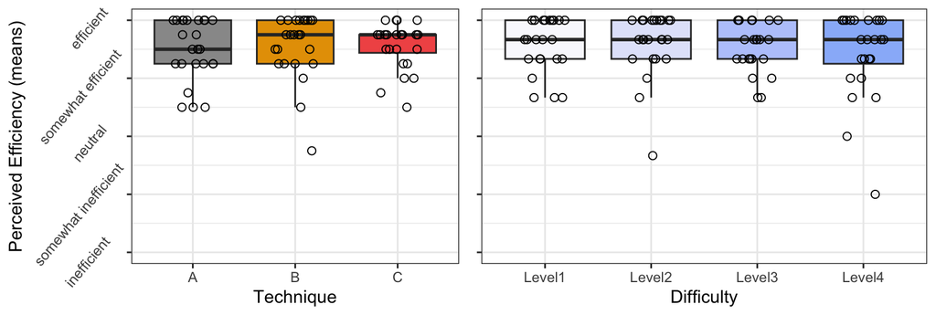

```r
# Plots for the perceived efficiency measure
dd1 <- df %>%  group_by(Participant,Technique) %>% summarise(Perceived_Efficiency = mean(as.integer(Perceived_Efficiency)), .groups="drop")

p3 <- (dd1 %>%
        ggplot(aes(x = Technique, y = Perceived_Efficiency, fill = Technique)) +
        geom_boxplot(outlier.shape = NA) +
        ylab("Perceived Efficiency (means)") +
        scale_y_continuous(breaks = 1:5, limits = c(1,5), labels=levels(df$Perceived_Efficiency)) +
        geom_jitter(shape=1, position=position_jitter(0.2,0), size = 2) +
        theme_bw() + theme(legend.position = "none")) + scale_fill_manual(values=cbPalette) +
        theme(axis.text.y=element_text(angle=50, hjust=0.7))

dd2 <- df %>%  group_by(Participant,Difficulty) %>% summarise(Perceived_Efficiency = mean(as.integer(Perceived_Efficiency)), .groups="drop")
diffPalette <- c("#f9f9fd", "#e2e6fa", "#bacafb", "#99b9f9")
p4 <- (dd2 %>%
        ggplot(aes(x = Difficulty, y = Perceived_Efficiency, fill = Difficulty)) +
        geom_boxplot(outlier.shape = NA) + ylim(1,5)+
        geom_jitter(shape=1, position=position_jitter(0.2,0), size = 2) +
        theme_bw() + theme(legend.position = "none")) + scale_fill_manual(values=diffPalette) +
        theme(axis.title.y=element_blank(), axis.text.y=element_blank())

grid.arrange(p3, p4, nrow = 1, widths = c(3, 3))
```

### Statistical analysis of time performance

For task-completion times, we conduct an analysis with five different methods: PAR, LOG, RNK, ART, and INT.

```r
# Implementation of the Inverse Normal Transform
int = function(x){
   qnorm((rank(x) - 0.5)/length(x))
}

mpar <- lmer(Time ~ Difficulty*Technique + (1|Participant), data=df) # Parametric - no transformation
mlog <- lmer(log(Time) ~ Difficulty*Technique + (1|Participant), data=df) # Parametric - Log-transformation
mart <- art(Time ~ Difficulty*Technique + (1|Participant), data=df) # ARTool
mrnk <- lmer(rank(Time) ~ Difficulty*Technique + (1|Participant), data=df) # Rank transformation
mint <- lmer(int(Time) ~ Difficulty*Technique + (1|Participant), data=df) # Inverse Transform transformation
```

#### Main and interaction effects

We report the results of our analysis.

```r
# Function for printing the results for each method
printAnalysis <- function(num, method, model) {
  cat(num, ". Analysis using ", method, "\n\n", sep="")

  print(anova(model))
  print(eta_squared(model))
  print(cohens_f(model))
}

printAnalysis(1, "Logarithmic Transformation", mlog)
```

```
## 1. Analysis using Logarithmic Transformation
##
## Type III Analysis of Variance Table with Satterthwaite's method
##                       Sum Sq Mean Sq NumDF DenDF  F value Pr(>F)
## Difficulty           184.009  61.336     3   253 156.7533 <2e-16 ***
## Technique              0.249   0.125     2   253   0.3182 0.7278
## Difficulty:Technique   1.796   0.299     6   253   0.7648 0.5982
## ---
## Signif. codes:  0 '***' 0.001 '**' 0.01 '*' 0.05 '.' 0.1 ' ' 1
## # Effect Size for ANOVA (Type III)
##
## Parameter            | Eta2 (partial) |       95% CI
## ----------------------------------------------------
## Difficulty           |           0.65 | [0.60, 1.00]
## Technique            |       2.51e-03 | [0.00, 1.00]
## Difficulty:Technique |           0.02 | [0.00, 1.00]
##
## - One-sided CIs: upper bound fixed at [1.00].# Effect Size for ANOVA (Type III)
##
## Parameter            | Cohen's f (partial) |      95% CI
## --------------------------------------------------------
## Difficulty           |                1.36 | [1.22, Inf]
## Technique            |                0.05 | [0.00, Inf]
## Difficulty:Technique |                0.13 | [0.00, Inf]
##
## - One-sided CIs: upper bound fixed at [Inf].
```

```r
printAnalysis(2, "ART", mart)
```

```
## 2. Analysis using ART
##
## Analysis of Variance of Aligned Rank Transformed Data
##
## Table Type: Analysis of Deviance Table (Type III Wald F tests with Kenward-Roger df)
## Model: Mixed Effects (lmer)
## Response: art(Time)
##
##                               F Df Df.res     Pr(>F)
## 1 Difficulty           126.4941  3    253 < 2.22e-16 ***
## 2 Technique              9.2273  2    253 0.00013554 ***
## 3 Difficulty:Technique   4.4645  6    253 0.00025746 ***
## ---
## Signif. codes:   0 '***' 0.001 '**' 0.01 '*' 0.05 '.' 0.1 ' ' 1
## # Effect Size for ANOVA (Type I)
##
## Parameter            | Eta2 (partial) |       95% CI
## ----------------------------------------------------
## Difficulty           |           0.60 | [0.54, 1.00]
## Technique            |           0.07 | [0.02, 1.00]
## Difficulty:Technique |           0.10 | [0.03, 1.00]
##
## - One-sided CIs: upper bound fixed at [1.00].# Effect Size for ANOVA (Type I)
##
## Parameter            | Cohen's f (partial) |      95% CI
## --------------------------------------------------------
## Difficulty           |                1.22 | [1.08, Inf]
## Technique            |                0.27 | [0.15, Inf]
## Difficulty:Technique |                0.33 | [0.18, Inf]
##
## - One-sided CIs: upper bound fixed at [Inf].
```

```r
printAnalysis(3, "Rank Transformation", mrnk)
```

```
## 3. Analysis using Rank Transformation
##
## Type III Analysis of Variance Table with Satterthwaite's method
##                      Sum Sq Mean Sq NumDF DenDF  F value Pr(>F)
## Difficulty           951821  317274     3   253 146.6506 <2e-16 ***
## Technique              2121    1060     2   253   0.4901 0.6131
## Difficulty:Technique   6104    1017     6   253   0.4702 0.8301
## ---
## Signif. codes:  0 '***' 0.001 '**' 0.01 '*' 0.05 '.' 0.1 ' ' 1
## # Effect Size for ANOVA (Type III)
##
## Parameter            | Eta2 (partial) |       95% CI
## ----------------------------------------------------
## Difficulty           |           0.63 | [0.58, 1.00]
## Technique            |       3.86e-03 | [0.00, 1.00]
## Difficulty:Technique |           0.01 | [0.00, 1.00]
##
## - One-sided CIs: upper bound fixed at [1.00].# Effect Size for ANOVA (Type III)
##
## Parameter            | Cohen's f (partial) |      95% CI
## --------------------------------------------------------
## Difficulty           |                1.32 | [1.17, Inf]
## Technique            |                0.06 | [0.00, Inf]
## Difficulty:Technique |                0.11 | [0.00, Inf]
##
## - One-sided CIs: upper bound fixed at [Inf].
```

```r
printAnalysis(4, "Inverse Normal Transformation", mint)
```

```
## 4. Analysis using Inverse Normal Transformation
##
## Type III Analysis of Variance Table with Satterthwaite's method
##                       Sum Sq Mean Sq NumDF DenDF  F value Pr(>F)
## Difficulty           134.160  44.720     3   253 151.6080 <2e-16 ***
## Technique              0.154   0.077     2   253   0.2603 0.7710
## Difficulty:Technique   1.345   0.224     6   253   0.7598 0.6022
## ---
## Signif. codes:  0 '***' 0.001 '**' 0.01 '*' 0.05 '.' 0.1 ' ' 1
## # Effect Size for ANOVA (Type III)
##
## Parameter            | Eta2 (partial) |       95% CI
## ----------------------------------------------------
## Difficulty           |           0.64 | [0.59, 1.00]
## Technique            |       2.05e-03 | [0.00, 1.00]
## Difficulty:Technique |           0.02 | [0.00, 1.00]
##
## - One-sided CIs: upper bound fixed at [1.00].# Effect Size for ANOVA (Type III)
##
## Parameter            | Cohen's f (partial) |      95% CI
## --------------------------------------------------------
## Difficulty           |                1.34 | [1.19, Inf]
## Technique            |                0.05 | [0.00, Inf]
## Difficulty:Technique |                0.13 | [0.00, Inf]
##
## - One-sided CIs: upper bound fixed at [Inf].
```

```r
printAnalysis(5, "No Transformation", mpar)
```

```
## 5. Analysis using No Transformation
##
## Type III Analysis of Variance Table with Satterthwaite's method
##                      Sum Sq Mean Sq NumDF DenDF F value Pr(>F)
## Difficulty           387.78 129.259     3   253 55.4618 <2e-16 ***
## Technique              8.06   4.031     2   253  1.7297 0.1794
## Difficulty:Technique  18.19   3.031     6   253  1.3007 0.2573
## ---
## Signif. codes:  0 '***' 0.001 '**' 0.01 '*' 0.05 '.' 0.1 ' ' 1
## # Effect Size for ANOVA (Type III)
##
## Parameter            | Eta2 (partial) |       95% CI
## ----------------------------------------------------
## Difficulty           |           0.40 | [0.32, 1.00]
## Technique            |           0.01 | [0.00, 1.00]
## Difficulty:Technique |           0.03 | [0.00, 1.00]
##
## - One-sided CIs: upper bound fixed at [1.00].# Effect Size for ANOVA (Type III)
##
## Parameter            | Cohen's f (partial) |      95% CI
## --------------------------------------------------------
## Difficulty           |                0.81 | [0.69, Inf]
## Technique            |                0.12 | [0.00, Inf]
## Difficulty:Technique |                0.18 | [0.00, Inf]
##
## - One-sided CIs: upper bound fixed at [Inf].
```

We observe that only ART shows statistical evidence for a main effect of Technique, as well as an interaction effect.

#### Contrasts

Finally, we conduct an analysis of pairwise differences between the three techniques *A*, *B*, and *C*, using a Bonferroni correction. For ART, we use the `art.con` function.

```r
library("emmeans")

# Function for printing the results for each method
printContrasts <- function(num, method, expr, model) {
  cat(num, ". Contrasts using ", method, "\n\n", sep="")

  if(method == "ART") art.con(model, expr, adjust = "bonferroni")
  else contrast(emmeans(model, expr), method="pairwise", adjust = "bonferroni")
}

printContrasts(1, "Logarithmic Transformation", ~Technique, mlog)
```

```
## 1. Contrasts using Logarithmic Transformation
```

```
## NOTE: Results may be misleading due to involvement in interactions
```

```
##  contrast estimate     SE  df t.ratio p.value
##  A - B     -0.0699 0.0903 253  -0.774  1.0000
##  A - C     -0.0500 0.0903 253  -0.554  1.0000
##  B - C      0.0199 0.0903 253   0.221  1.0000
##
## Results are averaged over the levels of: Difficulty
## Degrees-of-freedom method: kenward-roger
## Results are given on the log (not the response) scale.
## P value adjustment: bonferroni method for 3 tests
```

```r
printContrasts(2, "ART", ~Technique, mart)
```

```
## 2. Contrasts using ART
```

```
## NOTE: Results may be misleading due to involvement in interactions
```

```
##  contrast estimate   SE  df t.ratio p.value
##  A - B       -32.8 9.07 253  -3.611  0.0011
##  A - C         1.9 9.07 253   0.209  1.0000
##  B - C        34.7 9.07 253   3.820  0.0005
##
## Results are averaged over the levels of: Difficulty
## Degrees-of-freedom method: kenward-roger
## P value adjustment: bonferroni method for 3 tests
```

```r
printContrasts(3, "Rank Transformation", ~Technique, mrnk)
```

```
## 3. Contrasts using Rank Transformation
```

```
## NOTE: Results may be misleading due to involvement in interactions
```

```
##  contrast estimate   SE  df t.ratio p.value
##  A - B       -3.78 6.71 253  -0.563  1.0000
##  A - C       -6.62 6.71 253  -0.987  0.9740
##  B - C       -2.84 6.71 253  -0.424  1.0000
##
## Results are averaged over the levels of: Difficulty
## Note: contrasts are still on the rank scale
## Degrees-of-freedom method: kenward-roger
## P value adjustment: bonferroni method for 3 tests
```

```r
printContrasts(4, "Inverse Normal Transformation", ~Technique, mint)
```

```
## 4. Contrasts using Inverse Normal Transformation
```

```
## NOTE: Results may be misleading due to involvement in interactions
```

```
##  contrast estimate     SE  df t.ratio p.value
##  A - B     -0.0551 0.0784 253  -0.703  1.0000
##  A - C     -0.0387 0.0784 253  -0.493  1.0000
##  B - C      0.0164 0.0784 253   0.209  1.0000
##
## Results are averaged over the levels of: Difficulty
## Note: contrasts are still on the int scale
## Degrees-of-freedom method: kenward-roger
## P value adjustment: bonferroni method for 3 tests
```

```r
printContrasts(5, "No Transformation", ~Technique, mpar)
```

```
## 5. Contrasts using No Transformation
```

```
## NOTE: Results may be misleading due to involvement in interactions
```

```
##  contrast estimate   SE  df t.ratio p.value
##  A - B     -0.3857 0.22 253  -1.751  0.2437
##  A - C     -0.0729 0.22 253  -0.331  1.0000
##  B - C      0.3128 0.22 253   1.420  0.4708
##
## Results are averaged over the levels of: Difficulty
## Degrees-of-freedom method: kenward-roger
## P value adjustment: bonferroni method for 3 tests
```

We observe again a significant divergence between the results of ART and the results of the other methods.

### Statistical analysis of perceived efficiency

We conduct an analysis with PAR, RNK, ART, and INT.

```r
df$Perceived_Efficiency <- as.integer(df$Perceived_Efficiency)

mpar <- lmer(Perceived_Efficiency ~ Difficulty*Technique + (1|Participant), data=df) # Parametric - no transformation
mart <- art(Perceived_Efficiency ~ Difficulty*Technique + (1|Participant), data=df) # ARTool
mrnk <- lmer(rank(Perceived_Efficiency) ~ Difficulty*Technique + (1|Participant), data=df) # Rank transformation
mint <- lmer(int(Perceived_Efficiency) ~ Difficulty*Technique + (1|Participant), data=df) # Inverse Transform transformation
```

We report the results of our analysis.

```r
printAnalysis(2, "ART", mart)
```

```
## 2. Analysis using ART
##
## Analysis of Variance of Aligned Rank Transformed Data
##
## Table Type: Analysis of Deviance Table (Type III Wald F tests with Kenward-Roger df)
## Model: Mixed Effects (lmer)
## Response: art(Perceived_Efficiency)
##
##                             F Df Df.res     Pr(>F)
## 1 Difficulty           6.8803  3    253 0.00017965 ***
## 2 Technique            9.2319  2    253 0.00013496 ***
## 3 Difficulty:Technique 4.1418  6    253 0.00054717 ***
## ---
## Signif. codes:   0 '***' 0.001 '**' 0.01 '*' 0.05 '.' 0.1 ' ' 1
## # Effect Size for ANOVA (Type I)
##
## Parameter            | Eta2 (partial) |       95% CI
## ----------------------------------------------------
## Difficulty           |           0.08 | [0.03, 1.00]
## Technique            |           0.07 | [0.02, 1.00]
## Difficulty:Technique |           0.09 | [0.03, 1.00]
##
## - One-sided CIs: upper bound fixed at [1.00].# Effect Size for ANOVA (Type I)
##
## Parameter            | Cohen's f (partial) |      95% CI
## --------------------------------------------------------
## Difficulty           |                0.29 | [0.16, Inf]
## Technique            |                0.27 | [0.15, Inf]
## Difficulty:Technique |                0.31 | [0.16, Inf]
##
## - One-sided CIs: upper bound fixed at [Inf].
```

```r
printAnalysis(3, "Rank Transformation", mrnk)
```

```
## 3. Analysis using Rank Transformation
##
## Type III Analysis of Variance Table with Satterthwaite's method
##                       Sum Sq Mean Sq NumDF DenDF F value Pr(>F)
## Difficulty            8671.0  2890.3     3   253  0.7420 0.5279
## Technique              864.8   432.4     2   253  0.1110 0.8950
## Difficulty:Technique 26904.5  4484.1     6   253  1.1511 0.3333
## # Effect Size for ANOVA (Type III)
##
## Parameter            | Eta2 (partial) |       95% CI
## ----------------------------------------------------
## Difficulty           |       8.72e-03 | [0.00, 1.00]
## Technique            |       8.77e-04 | [0.00, 1.00]
## Difficulty:Technique |           0.03 | [0.00, 1.00]
##
## - One-sided CIs: upper bound fixed at [1.00].# Effect Size for ANOVA (Type III)
##
## Parameter            | Cohen's f (partial) |      95% CI
## --------------------------------------------------------
## Difficulty           |                0.09 | [0.00, Inf]
## Technique            |                0.03 | [0.00, Inf]
## Difficulty:Technique |                0.17 | [0.00, Inf]
##
## - One-sided CIs: upper bound fixed at [Inf].
```

```r
printAnalysis(4, "Inverse Normal Transformation", mint)
```

```
## 4. Analysis using Inverse Normal Transformation
##
## Type III Analysis of Variance Table with Satterthwaite's method
##                       Sum Sq Mean Sq NumDF DenDF F value Pr(>F)
## Difficulty           1.14581 0.38194     3   253  0.8113 0.4886
## Technique            0.18713 0.09357     2   253  0.1988 0.8199
## Difficulty:Technique 2.80391 0.46732     6   253  0.9927 0.4307
## # Effect Size for ANOVA (Type III)
##
## Parameter            | Eta2 (partial) |       95% CI
## ----------------------------------------------------
## Difficulty           |       9.53e-03 | [0.00, 1.00]
## Technique            |       1.57e-03 | [0.00, 1.00]
## Difficulty:Technique |           0.02 | [0.00, 1.00]
##
## - One-sided CIs: upper bound fixed at [1.00].# Effect Size for ANOVA (Type III)
##
## Parameter            | Cohen's f (partial) |      95% CI
## --------------------------------------------------------
## Difficulty           |                0.10 | [0.00, Inf]
## Technique            |                0.04 | [0.00, Inf]
## Difficulty:Technique |                0.15 | [0.00, Inf]
##
## - One-sided CIs: upper bound fixed at [Inf].
```

```r
printAnalysis(5, "No Transformation", mpar)
```

```
## 5. Analysis using No Transformation
##
## Type III Analysis of Variance Table with Satterthwaite's method
##                       Sum Sq Mean Sq NumDF DenDF F value Pr(>F)
## Difficulty           1.48264 0.49421     3   253  0.9242 0.4296
## Technique            0.34028 0.17014     2   253  0.3182 0.7278
## Difficulty:Technique 2.63194 0.43866     6   253  0.8203 0.5550
## # Effect Size for ANOVA (Type III)
##
## Parameter            | Eta2 (partial) |       95% CI
## ----------------------------------------------------
## Difficulty           |           0.01 | [0.00, 1.00]
## Technique            |       2.51e-03 | [0.00, 1.00]
## Difficulty:Technique |           0.02 | [0.00, 1.00]
##
## - One-sided CIs: upper bound fixed at [1.00].# Effect Size for ANOVA (Type III)
##
## Parameter            | Cohen's f (partial) |      95% CI
## --------------------------------------------------------
## Difficulty           |                0.10 | [0.00, Inf]
## Technique            |                0.05 | [0.00, Inf]
## Difficulty:Technique |                0.14 | [0.00, Inf]
##
## - One-sided CIs: upper bound fixed at [Inf].
```

We also report an analysis with the Friedman test, after aggregating the dataset, either by *Difficulty* or by *Technique*.

```r
df_diff <- df %>%
  group_by(Participant, Difficulty) %>%
  summarise(Perceived_Efficiency = mean(Perceived_Efficiency), .groups = "drop")
friedman.test(Perceived_Efficiency ~ Difficulty | Participant, data = df_diff)
```

```
##
##  Friedman rank sum test
##
## data:  Perceived_Efficiency and Difficulty and Participant
## Friedman chi-squared = 0.80952, df = 3, p-value = 0.8472
```

```r
df_tech <- df %>%
  group_by(Participant, Technique) %>%
  summarise(Perceived_Efficiency = mean(Perceived_Efficiency), .groups = "drop")
friedman.test(Perceived_Efficiency ~ Technique | Participant, data = df_tech)
```

```
##
##  Friedman rank sum test
##
## data:  Perceived_Efficiency and Technique and Participant
## Friedman chi-squared = 0.17284, df = 2, p-value = 0.9172
```

Again, ART is the only method to detect an main effect for both Difficulty and Technique, as well as an interaction effect. Its *p-*values are orders of magnitude lower than the *p-*values returned by the other methods.